# Network Attributes by Walkshed

Antonio Paez

2024-12-10

**NOTE:** Notebook takes about 7 hours to run.

In this document we aim to partition the network based on walksheds.

We tried smoothing the pseudo-nodes, but this process messed up with the geometry of the network which affects some of the network analysis, so we decided not to proceed. Instead, we use the network as is. Intersecting the network mutilates all edges that cross the boundary of the pedshed. To avoid this we keep track of the indices of the edges that intersect the pedshed and then retrieve them from the network.

# Preliminaries

Load packages:

```r
library(dplyr) # A Grammar of Data Manipulation
library(ggraph) # An Implementation of Grammar of Graphics for Graphs and Networks
library(ggplot2) # Create Elegant Data Visualisations Using the Grammar of Graphics
library(glue) # Interpreted String Literals
library(here) # A Simpler Way to Find Your Files
library(igraph) # Network Analysis and Visualization
library(patchwork) # The Composer of Plots
library(skimr) # Compact and Flexible Summaries of Data
library(sf) # Simple Features for R
library(sfnetworks) # Tidy Geospatial Networks
library(tidyr) # Tidy Messy Data
```

```r
load(file = glue::glue(here::here(),
                       "/data/hamilton_net.rda"))
load(file = glue::glue(here::here(),
                       "/data/urban_hammer_da.rda"))
load(file = glue::glue(here::here(),
                       "/data/walksheds_da.rda"))
load(file = glue::glue(here::here(),
                       "/data/walksheds_validation.rda"))
```

Bind the centroid and non-centroid walksheds (da and validations, but bound could be used in more imaginative ways for cross-validation, for example):

```r
walksheds <- bind_rows(walksheds_da,
                       walksheds_validation) |>
  mutate(origin_type = rep(c("centroid", "non-centroid"), each = nrow(walksheds_da)))
```

Obtain training and validation datasets by sampling from centroid and non-centroid walksheds:

```r
seed <- 3626425

# slice_sample() will select one of two rows for each DA at random
walksheds_train <- walksheds |>
  group_by(GeoUID) |>
  slice_sample(prop = 0.5)

# The antijoin will keep the rows in walksheds that do not appear in walksheds_train
walksheds_test <- walksheds |>
  anti_join(walksheds_train |>
              st_drop_geometry() |>
              select(GeoUID, origin_type),
            by = c("GeoUID", "origin_type"))
```

Bind the centroid and non-centroid dataframes (da and validations):

```r
walksheds <- bind_rows(walksheds_train,
                                walksheds_validation) |>
  mutate(origin_type = rep(c("centroid", "non-centroid"), each = nrow(walksheds_da)))
```

Extract the edges of the network:

```r
hamilton_edges <- hamilton_net$edges
```

Calculate network attributes by walkshed:

```r
# Time algorithm
start.time <- Sys.time()

# Initialize data frame
walksheds_da_net_vars <- data.frame(GeoUID = walksheds_da$GeoUID,
                                    n_nodes = numeric(nrow(walksheds_da)),
                                    transitivity = numeric(nrow(walksheds_da)),
                                    motifs_3 = numeric(nrow(walksheds_da)),
                                    motifs_4 = numeric(nrow(walksheds_da)),
                                    n_edges = numeric(nrow(walksheds_da)),
                                    diameter = numeric(nrow(walksheds_da)),
                                    radius = numeric(nrow(walksheds_da)),
                                    girth = numeric(nrow(walksheds_da)),
                                    global_efficiency = numeric(nrow(walksheds_da)),
                                    edge_density = numeric(nrow(walksheds_da)),
                                    edge_connectivity = numeric(nrow(walksheds_da)),
                                    mean_distance = numeric(nrow(walksheds_da)),
                                    min_cut = numeric(nrow(walksheds_da)))

for(i in 1:nrow(walksheds_da)){
  # Find the intersection between the edges and the walksheds. The edges will be truncated, but the indices can be used to retrieve the full edges.
  wsnet <- hamilton_edges |>
    st_filter(
      walksheds_da[i,],
      .predicate = st_intersects)

  # Extract the full edges that were found to intersect the walkshed
  wsnet <- hamilton_edges |>
    filter(edge_index %in% wsnet$edge_index)

  # Convert to sfnetwork
  wsnet <- as_sfnetwork(wsnet)

  E(wsnet)$weight <- E(wsnet)$length
  walksheds_da_net_vars$n_nodes[i] <- gorder(wsnet)
  walksheds_da_net_vars$transitivity[i] <- transitivity(wsnet)
  walksheds_da_net_vars$motifs_3[i] <- count_motifs(wsnet, size = 3)
  walksheds_da_net_vars$motifs_4[i] <- count_motifs(wsnet, size = 4)
  walksheds_da_net_vars$n_edges[i] <- gsize(wsnet)
  walksheds_da_net_vars$diameter[i] <- diameter(wsnet)
  walksheds_da_net_vars$radius[i] <- radius(wsnet)
  walksheds_da_net_vars$girth[i] <- girth(wsnet)$girth
  walksheds_da_net_vars$global_efficiency[i] <- global_efficiency(wsnet)
  walksheds_da_net_vars$edge_density[i] <- edge_density(wsnet)
  walksheds_da_net_vars$edge_connectivity[i] <- edge_connectivity(wsnet)
  walksheds_da_net_vars$mean_distance[i] <- mean_distance(wsnet)
  walksheds_da_net_vars$min_cut[i] <- min_cut(wsnet)
}

end.time <- Sys.time()
time.taken <- end.time - start.time
time.taken
```

Join the type of urban fabric:

```r
walksheds_da_net_vars <- walksheds_da_net_vars |>
  mutate(Type = walksheds_da$Type) |>
  select(GeoUID, Type, n_nodes:min_cut)
```

Save the data object:

```r
save(walksheds_da_net_vars,
     file = glue::glue(here::here(), "/data/walksheds_da_net_vars.rda"),
     compress = "xz")
```

Calculate network attributes by walkshed for the validation set:

```r
# Time algorithm
start.time <- Sys.time()

# Initialize data frame
walksheds_validation_net_vars <- data.frame(GeoUID = walksheds_validation$GeoUID,
                                            n_nodes = numeric(nrow(walksheds_validation)),
                                            transitivity = numeric(nrow(walksheds_validation)),
                                            motifs_3 = numeric(nrow(walksheds_validation)),
                                            motifs_4 = numeric(nrow(walksheds_validation)),
                                            n_edges = numeric(nrow(walksheds_validation)),
                                            diameter = numeric(nrow(walksheds_validation)),
                                            radius = numeric(nrow(walksheds_validation)),
                                            girth = numeric(nrow(walksheds_validation)),
                                            global_efficiency = numeric(nrow(walksheds_validation)),
                                            edge_density = numeric(nrow(walksheds_validation)),
                                            edge_connectivity = numeric(nrow(walksheds_validation)),
                                            mean_distance = numeric(nrow(walksheds_validation)),
                                            min_cut = numeric(nrow(walksheds_validation)))

for(i in 1:nrow(walksheds_validation)){
  # Find the intersection between the edges and the walksheds. The edges will be truncated, but the indices can be used to retrieve the full edges.
  wsnet <- hamilton_edges |>
    st_filter(
      walksheds_validation[i,],
      .predicate = st_intersects)

  # Extract the full edges that were found to intersect the walkshed
  wsnet <- hamilton_edges |>
    filter(edge_index %in% wsnet$edge_index)

  # Convert to sfnetwork
  wsnet <- as_sfnetwork(wsnet)

  E(wsnet)$weight <- E(wsnet)$length
  walksheds_validation_net_vars$n_nodes[i] <- gorder(wsnet)
  walksheds_validation_net_vars$transitivity[i] <- transitivity(wsnet)
  walksheds_validation_net_vars$motifs_3[i] <- count_motifs(wsnet, size = 3)
  walksheds_validation_net_vars$motifs_4[i] <- count_motifs(wsnet, size = 4)
  walksheds_validation_net_vars$n_edges[i] <- gsize(wsnet)
  walksheds_validation_net_vars$diameter[i] <- diameter(wsnet)
  walksheds_validation_net_vars$radius[i] <- radius(wsnet)
  walksheds_validation_net_vars$girth[i] <- girth(wsnet)$girth
  walksheds_validation_net_vars$global_efficiency[i] <- global_efficiency(wsnet)
  walksheds_validation_net_vars$edge_density[i] <- edge_density(wsnet)
  walksheds_validation_net_vars$edge_connectivity[i] <- edge_connectivity(wsnet)
  walksheds_validation_net_vars$mean_distance[i] <- mean_distance(wsnet)
  walksheds_validation_net_vars$min_cut[i] <- min_cut(wsnet)
}

end.time <- Sys.time()
time.taken <- end.time - start.time
time.taken
```

Join the type of urban fabric:

```r
walksheds_validation_net_vars <- walksheds_validation_net_vars |>
  mutate(Type = walksheds_validation$Type) |>
  select(GeoUID, Type, n_nodes:min_cut)
```

Save the data object:

```r
save(walksheds_validation_net_vars,
     file = glue::glue(here::here(),
                       "/data/walksheds_validation_net_vars.rda"),
     compress = "xz")
```

Summarize. Notice that `girth` is problematic for the skim, although it can be examined with `summary()`:

```r
walksheds_da_net_vars |>
  select(-girth) |>
  group_by(Type) |>
  skim()
```

Summarize the walksheds:

```r
walksheds_validation_net_vars |>
  select(-girth) |>
  group_by(Type) |>
  skim()
```

Edge connectivity is not super useful: there is little variation - it is a measure of network vulnerability, minimum number of edges to remove to disconnect two nodes (there is no longer a path between them.)

Transitivity: it is the probability that the neighbors of a node are neighbors between them. In a Manhattan-style grid this number will be low because there will be lots and lots of squares.

Motifs (calculated for size 3 and 4): It indicates the presence of particular subgraphs that repeat themselves. In other words, a graph with a large number of motifs will tend to have few unique elements (some elements happen again, again, and again). A graph with many unique elements will have few motifs (repetitive patterns).

Bind the centroid and non-centroid dataframes with walkshed network variables (da and validations):

```r
walksheds_net_vars <- bind_rows(walksheds_da_net_vars,
                                walksheds_validation_net_vars) |>
  mutate(origin_type = rep(c("centroid", "non-centroid"), each = nrow(walksheds_da)))
```

Now filter from the network variables to obtain training and test datasets:

```r
walksheds_train_net_vars <- walksheds_net_vars |>
  semi_join(walksheds_train |>
              st_drop_geometry() |>
              select(GeoUID, origin_type),
            by = c("GeoUID", "origin_type"))

walksheds_test_net_vars <- walksheds_net_vars |>
  semi_join(walksheds_test |>
              st_drop_geometry() |>
              select(GeoUID, origin_type),
            by = c("GeoUID", "origin_type"))
```

Example of pedshed with network:

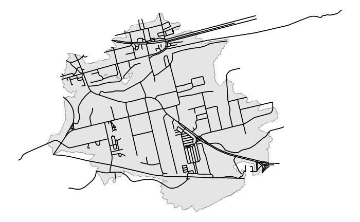

```r
sample_walkshed <- sample.int(nrow(walksheds), 1)

wsnet <- hamilton_edges |>
  st_filter(
    walksheds[sample_walkshed,],
    .predicate = st_intersects)

# Extract the full edges that were found to intersect the walkshed
wsnet <- hamilton_edges |>
  filter(edge_index %in% wsnet$edge_index)

ggplot() +
  geom_sf(data = walksheds[sample_walkshed,]) +
  geom_sf(data = wsnet) +
  theme_void()
```

Explore the motifs. First, extract a walkshed and convert it to sfnetworks class:

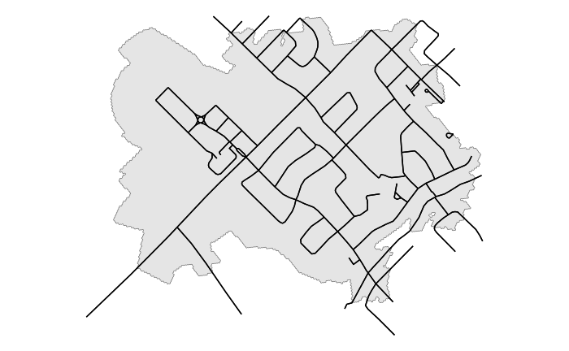

```r
sample_walkshed <- sample.int(nrow(walksheds), 1)

wsnet <- hamilton_edges |>
  st_filter(
    walksheds[sample_walkshed,],
    .predicate = st_intersects)

# Extract the full edges that were found to intersect the walkshed
wsnet <- hamilton_edges |>
  filter(edge_index %in% wsnet$edge_index)

# Convert to sfnetwork
wsnet <- as_sfnetwork(wsnet)

ggplot() +
  geom_sf(data = walksheds[sample_walkshed,]) +
  geom_sf(data = wsnet |>
            activate(edges) |>
            st_as_sf()
  ) +
  theme_void()
```

Note that there are 16 classes of directed isomorphic graphs of size 3. Here numbers 1 and 15 are obtained:

```r
# Size is the number of nodes, number is the isomorphic class, directed true
g1 <- graph_from_isomorphism_class(size = 3, number = 1, directed = TRUE)
g15 <- graph_from_isomorphism_class(size = 3, number = 15, directed = TRUE)
```

Plot isomorphism:

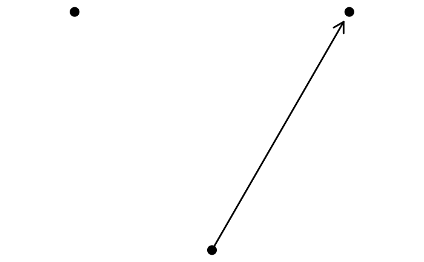

```r
ggraph(g1, layout = "linear", circular = TRUE) +
  geom_edge_fan2(arrow = arrow(length = unit(5, 'mm')),
                 end_cap = circle(5, 'mm'),
                 lineend = "round",
                 width = 1) +
  geom_node_point(size = 5) +
  coord_equal() +
  theme_void()
```

Obtain all directed isomorphisms of size 3:

```r
size_3_iso <- purrr::map(1:15,
                         ~graph_from_isomorphism_class(size = 3,
                                                       number = .x,
                                                       directed = TRUE))
```

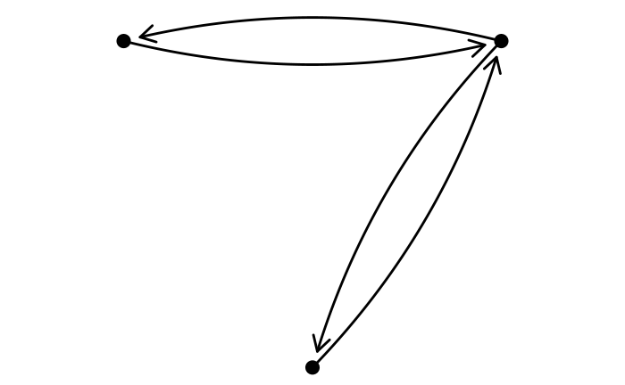

```r
ggraph(size_3_iso[[10]], layout = "linear", circular = TRUE) +
  geom_edge_fan2(arrow = arrow(length = unit(5, 'mm')),
                 end_cap = circle(5, 'mm'),
                 lineend = "round",
                 width = 1) +
  geom_node_point(size = 5) +
  coord_equal() +
  theme_void()
```

Motifs of size 3 in wsnet:

```r
motifs(wsnet)
```

[output not shown]

The most common by far is class 10.

```r
count_motifs(wsnet)
```

Initialize a data frame to save the motif counts:

```r
walksheds_motif_3_count <- data.frame(matrix(0, nrow = nrow(walksheds), ncol = 16))

walksheds_motif_3_count <- walksheds_motif_3_count |>
  rename_with(~ paste0("iso_class_", c(0:15)), starts_with("X"))

DA <- numeric(length = nrow(walksheds))
TYPE <- numeric(length = nrow(walksheds))
```

Compute the number of motifs of each class in the walksheds:

```r
# Time algorithm
start.time <- Sys.time()

for(i in 1:nrow(walksheds)){
  #wsnet <- hamilton_edges |>
    st_filter(
      walksheds[i,],
      .predicate = st_intersects)

  wsnet <- hamilton_edges |>
    filter(edge_index %in% wsnet$edge_index)

  # Convert to sfnetwork
  wsnet <- as_sfnetwork(wsnet)
  walksheds_motif_3_count[i,] <- motifs(wsnet)
}

walksheds_motif_3_count <- walksheds_motif_3_count |>
  mutate(GeoUID = walksheds$GeoUID,
         Type = walksheds$Type,
         origin_type = walksheds$origin_type) |>
  select(GeoUID, Type, origin_type, starts_with("iso"))

end.time <- Sys.time()
time.taken <- end.time - start.time
time.taken
```

Save the data object:

```r
save(walksheds_motif_3_count,
     file = glue::glue(here::here(), "/data/walksheds_motif_3_count.rda"),
     compress = "xz")
```

Summary of motif counts:

```r
summary(walksheds_motif_3_count)
```

The only motifs present are class 10 and class 15:

```r
iso_3_10_plot <- ggraph(size_3_iso[[10]], layout = "linear", circular = TRUE) +
  geom_edge_fan2(arrow = arrow(length = unit(5, 'mm')),
                 end_cap = circle(5, 'mm'),
                 lineend = "round",
                 width = 1) +
  geom_node_point(size = 5) +
  coord_equal() +
  theme_void()

iso_3_15_plot <- ggraph(size_3_iso[[15]], layout = "linear", circular = TRUE) +
  geom_edge_fan2(arrow = arrow(length = unit(5, 'mm')),
                 end_cap = circle(5, 'mm'),
                 lineend = "round",
                 width = 1) +
  geom_node_point(size = 5) +
  coord_equal() +
  theme_void()

iso_3_10_plot + iso_3_15_plot
```

[output not shown]

Check walksheds with low number of motifs (normalized):

```r
d <- walksheds_net_vars |>
                  drop_na() |>
  mutate(normalized_motifs_3 = motifs_3/n_edges,
         normalized_motifs_4 = motifs_4/n_edges)

d |> filter(normalized_motifs_3 < 0.7)
```

Choose a walkshed with low number of motifs:

```r
ID <- "35250947" #"35250992"# "35250317"

wsnet <- hamilton_edges |>
  st_filter(
    walksheds |> filter(GeoUID == ID, origin_type == "centroid"),
    .predicate = st_intersects)

# Extract the full edges that were found to intersect the walkshed
wsnet <- hamilton_edges |>
  filter(edge_index %in% wsnet$edge_index)

# Convert to sfnetwork
wsnet <- as_sfnetwork(wsnet)
```

Plot chosen walkshed:

```r
ggplot()  +
  geom_sf(data = urban_hammer_da |>
            filter(GeoUID == ID),
          fill = "red") +
  geom_sf(data = walksheds |>
            filter(GeoUID == ID),
          color = "blue",
          fill = "blue") +
  geom_sf(data = wsnet |>
            activate(edges) |>
            st_as_sf())
```

Find the motifs of class 10 and 15 in wsnet:

```r
iso_class_10_list <- subgraph_isomorphisms(size_3_iso[[10]],
                                           wsnet,
                                           method = "vf2")

iso_class_15_list <- subgraph_isomorphisms(size_3_iso[[15]],
                                           wsnet,
                                           method = "vf2")
```

The elements in the list that results are triads of nodes.

```r
subgraph(wsnet, vids = iso_class_10_list[[1]]) |>
  as_sfnetwork()
```

Extract the isomorphs of class 10 from the network:

```r
# This is the first one in the list
motifs_class_10 <- subgraph(wsnet, vids = iso_class_10_list[[1]]) |>
  as_sfnetwork()

# Join every other isomorph in the list
for(i in 2:length(iso_class_10_list)){
  motifs_class_10 <- st_network_join(motifs_class_10,
                   subgraph(wsnet, vids = iso_class_10_list[[i]]) |>
                     as_sfnetwork())
}
```

Extract the isomorphs of class 15 from the network:

```r
# This is the first one in the list
motifs_class_15 <- subgraph(wsnet, vids = iso_class_15_list[[1]]) |>
  as_sfnetwork()

# Join every other isomorph in the list
for(i in 2:length(iso_class_15_list)){
  motifs_class_15 <- st_network_join(motifs_class_15,
                   subgraph(wsnet, vids = iso_class_15_list[[i]]) |>
                     as_sfnetwork())
}
```

Plot the motifs of class 10 and 15:

```r
ggplot() +
  geom_sf(data = walksheds_da |>
            filter(GeoUID == ID)) +
  geom_sf(data = wsnet |>
            activate(edges) |>
            st_as_sf()) +
  geom_sf(data = motifs_class_10 |>
            activate(edges) |>
            st_as_sf(),
          color = "red") +
  geom_sf(data = motifs_class_15 |>
            activate(edges) |>
            st_as_sf(),
          color = "blue") +
  theme_void()
```

[output not shown]

Almost all elements of the network are part of a motif. But the number of motifs is low, which suggests that a large number of dead ends tends to reduce the number of motifs.

Check walksheds with high number of motifs (normalized):

```r
d |> filter(normalized_motifs_3 > 1.07)
```

```r
ID <- "35250675" #

wsnet <- hamilton_edges |>
  st_filter(
    walksheds |> filter(GeoUID == ID, origin_type == "centroid"),
    .predicate = st_intersects)

# Extract the full edges that were found to intersect the walkshed
wsnet <- hamilton_edges |>
  filter(edge_index %in% wsnet$edge_index)

# Convert to sfnetwork
wsnet <- as_sfnetwork(wsnet)
```

Find the motifs of class 10 and 15 in wsnet:

```r
iso_class_10_list <- subgraph_isomorphisms(size_3_iso[[10]],
                                           wsnet,
                                           method = "vf2")

iso_class_15_list <- subgraph_isomorphisms(size_3_iso[[15]],
                                           wsnet,
                                           method = "vf2")
```

Extract the isomorphs of class 10 from the network:

```r
# This is the first one in the list
motifs_class_10 <- subgraph(wsnet, vids = iso_class_10_list[[1]]) |>
  as_sfnetwork()

# Join every other isomorph in the list
for(i in 2:length(iso_class_10_list)){
  motifs_class_10 <- st_network_join(motifs_class_10,
                   subgraph(wsnet, vids = iso_class_10_list[[i]]) |>
                     as_sfnetwork())
}
```

Extract the isomorphs of class 15 from the network:

```r
# This is the first one in the list
motifs_class_15 <- subgraph(wsnet, vids = iso_class_15_list[[1]]) |>
  as_sfnetwork()

# Join every other isomorph in the list
for(i in 2:length(iso_class_15_list)){
  motifs_class_15 <- st_network_join(motifs_class_15,
                   subgraph(wsnet, vids = iso_class_15_list[[i]]) |>
                     as_sfnetwork())
}
```

Plot the motifs of class both classes:

```r
ggplot() +
  geom_sf(data = walksheds |>
            filter(GeoUID == ID, origin_type == "centroid")) +
  geom_sf(data = wsnet |>
            activate(edges) |>
            st_as_sf()) +
  geom_sf(data = motifs_class_10 |>
            activate(edges) |>
            st_as_sf(),
          color = "red") +
  geom_sf(data = motifs_class_15 |>
            activate(edges) |>
            st_as_sf(),
          color = "blue") +
  theme_void()
```

Degree distribution:

```r
ggplot(data = data.frame(degree = degree(wsnet)) |>
         mutate(degree = factor(degree,
                                ordered = TRUE))|>
         group_by(degree) |>
         summarize(count = n())) +
  geom_col(aes(x = degree, y = count))
```

```r
wsnet <- hamilton_edges |>
  st_filter(
    walksheds_da |> filter(GeoUID == ID),
    .predicate = st_intersects)

# Extract the full edges that were found to intersect the walkshed
wsnet <- hamilton_edges |>
  filter(edge_index %in% wsnet$edge_index)

# Convert to sfnetwork
wsnet <- as_sfnetwork(wsnet)
```

Compute the degree distribution in the walksheds:

```r
# Time algorithm
start.time <- Sys.time()

# Initialize a dataframe
walksheds_da_degree_dist <- data.frame(GeoUID = numeric(), degree = numeric())

for(i in 1:nrow(walksheds_da)){
  wsnet <- hamilton_edges |>
    st_filter(
      walksheds_da[i,],
      .predicate = st_intersects)

  wsnet <- hamilton_edges |>
    filter(edge_index %in% wsnet$edge_index)

  # Convert to sfnetwork
  wsnet <- as_sfnetwork(wsnet)
  walksheds_da_degree_dist <- rbind(walksheds_da_degree_dist,
                                    data.frame(GeoUID = walksheds_da$GeoUID[i],
                                               degree = degree(wsnet)))
}

end.time <- Sys.time()
time.taken <- end.time - start.time
time.taken
```

Time difference:

```r
time.taken
```

Join urban fabric types:

```r
walksheds_da_degree_dist <- walksheds_da_degree_dist |>
  left_join(walksheds_da |>
              st_drop_geometry(),
            by = "GeoUID")
```

Save object:

```r
save(walksheds_da_degree_dist,
     file = glue::glue(here::here(), "/data/walksheds_da_degree_dist.rda"),
     compress = "xz")
```

```r
walksheds_da_degree_dist |>
  mutate(degree = factor(degree,
                         ordered = TRUE)) |>
         group_by(Type, degree) |>
         summarize(count = n(),
                   .groups = "drop") |>
  ggplot() +
  geom_col(aes(x = degree, y = count, fill = Type), position = "dodge")
```